# 06_analysis_2

## Loading libraries and loading the data

```r
library(tidyverse)

aug_data <- read_tsv("../data/03_aug_data.tsv")

#making sure that the columns is the right type
source("09_proj_func.R")
aug_data <- char_type_col(aug_data)
```

## Defining colors and theme

```r
my_cols <- c("#da9283" ,"#7A1F15","#94BFBE","#627634","#C03221","#545E75",
              "#3C3C68","#474B24")

theme_custom <- theme_minimal(base_size = 14) +

  theme(
    plot.title = element_text(face = "bold",
                              size = 13,
                              margin = margin(b = 7)
                              ),

    plot.subtitle = element_text(size = 10,
                                 margin = margin(b = 12)
                                 ),

    plot.caption = element_text(size = 8,
                                margin = margin(t = 20)
                                ),

    axis.title.x = element_text(size = 10,
                                margin = margin(t = 10)
                                ),

    axis.title.y = element_text(size = 10,
                                margin = margin(r = 10)
                                ),

    axis.text.x = element_text(size = 10,
                               margin = margin(t = 5)
                               ),

    axis.text.y = element_text(size = 10,
                               margin = margin(r = 5)
                               ),

    legend.position = "none",
    )
```

## Analysis of Fmax and SAA results

Seed Amplification Assays (SAA) detect α-synuclein aggregates in cerebrospinal fluid (CSF) and monitors fluorescence intensity over time. The point at which fluorescence reaches its maximum (Fmax) reflects the level of α-synuclein aggregation and is therefore a potential diagnostic indicator for Parkinson’s disease (PD).

The two projects perform the assays under different variables:

- **Project 155**: 150-hour assay, fluorescence measured every 29 minutes
- **Project 237**: 24-hour assay, fluorescence measured every 14 minutes

Variations in assay duration, cycle length, and reaction mixture composition mean that fluorescence values (Fmax) are not directly comparable across projects.

Because assay duration, cycle frequency, and reaction mixture differ between projects, fluorescence values (Fmax) cannot be directly compared without looking at protocol-specific characteristics.

We will look at the separation and overlap in fmax, when determining SAA result.

## SAA result distribution

We will look at how the ratio of negative, positive and inconclusive is

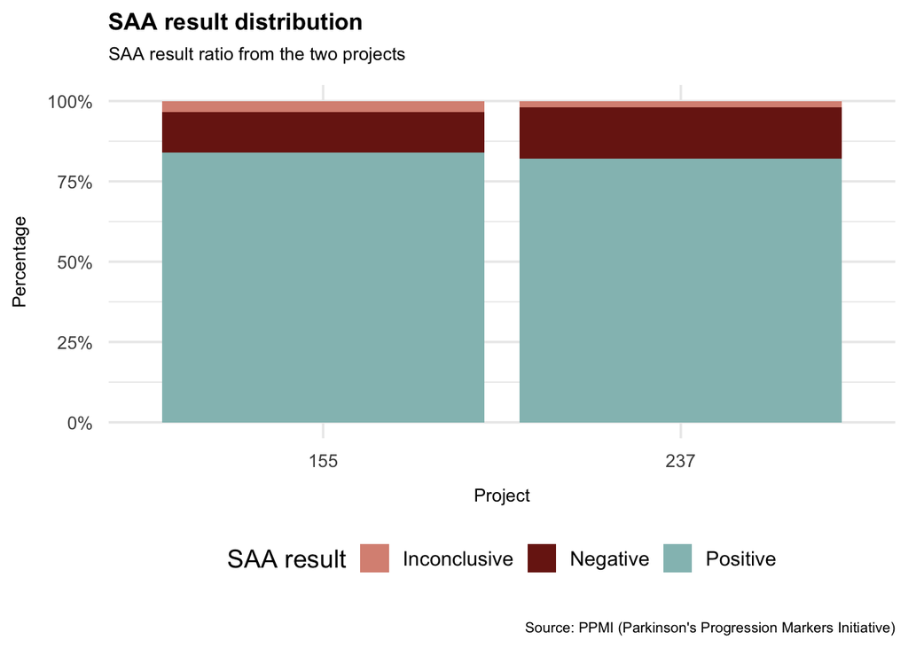

```r
aug_data |>
  ggplot(mapping = aes(x = project)) +
  geom_bar(mapping = aes(fill = saa_result),
           position = "fill") +

  scale_fill_manual(values = c("#da9283","#7A1F15","#94BFBE"),
                    name = "SAA result",
                    guide = guide_legend(nrow = 1)) +

  theme_custom +
  theme(legend.position = "bottom") +
  labs(title = "SAA result distribution",
       subtitle = "SAA result ratio from the two projects",
       x = "Project",
       caption = "Source: PPMI (Parkinson's Progression Markers Initiative)") +

    scale_y_continuous(name = "Percentage",
                       labels = scales::label_percent(accuracy = 1))
```

(very hard to figure out how to do the percent labels) **stacked plot with percent labels:**

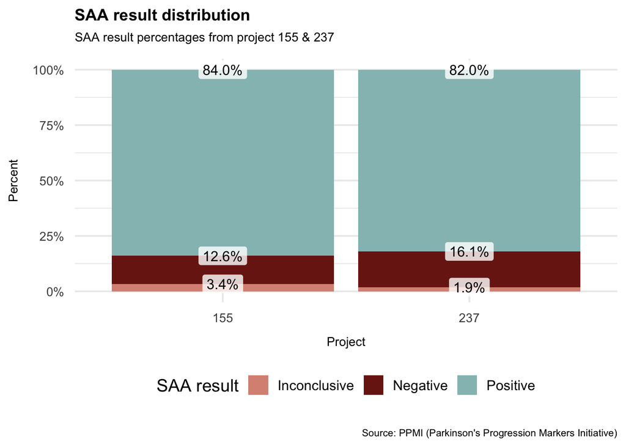

```r
saa_result_dist <- aug_data |>
  group_by(project) |>
  count(saa_result) |>
  mutate(pct = prop.table(n)) |>

  ggplot(aes(x = project,
             y = pct,
             fill = saa_result,
             label = scales::percent(pct))) +

  geom_col(position = position_stack(reverse = TRUE)) +

  geom_label(position = position_stack(reverse = TRUE),
            fill = "white",
            alpha = 0.8,
            label.size = 0,
            size = 4) +

  scale_y_continuous(labels = scales::percent) +

  scale_fill_manual(values = c("#da9283","#7A1F15","#94BFBE"),
                    name = "SAA result",
                    guide = guide_legend(nrow = 1)) +
  theme_custom +
  theme(legend.position = "bottom") +
  labs(title = "SAA result distribution",
       subtitle = "SAA result percentages from project 155 & 237",
       y = "Percent",
       x = "Project",
       caption = "Source: PPMI (Parkinson's Progression Markers Initiative)")

ggsave(filename = "../results/06_saa_result_dist.png",
       width = 10,
       height = 7)

saa_result_dist
```

It seems to be very similar - not a very big difference in the ratio. Trying to see the separation:

## Analysis of Fmax_mean as alternative test parameter

In this section we will test the variable Fmax_mean as a valid predictor of test result status. Fmax_mean is a mean calculated from the three samples collected in every assay.

## Test distinction by way of Fmax_mean

First we select the 150h test group from the dataset, and then we plot the Fmax_mean grouped by their result status(positive/negative/inconclusive) and do a visual inspection and evaluate if the groups are distinguishable.

```r
fmax_mean_results_150h <- aug_data |>
  filter(project == "155") |>
  ggplot(aes(
    x = saa_result,
    y = fmax_mean,
    fill = saa_result)
    ) +

  geom_boxplot(outlier.alpha = 0.3) +

  scale_color_manual(values = my_cols) +
  scale_fill_manual(values = my_cols) +

  labs(
    title = "150h Metrics by SAA Status",
    y = "Fmax mean",
    x = NULL,
    caption = "Source: PPMI (Parkinson's Progression Markers Initiative)"
    ) +
  theme_custom
```

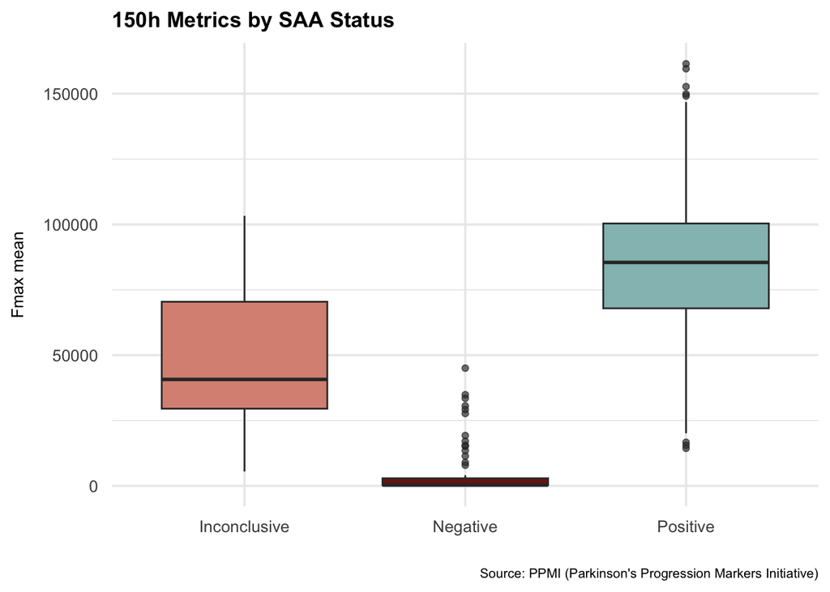

```r
fmax_mean_results_150h
```

```r
ggsave(filename = "../results/06_fmax_mean_results_150h.png",
       width = 10,
       height = 5)
```

From the plot we see that that the positive and negative group is distinguishable so we conduct a t-test to evaluate if we can predict what group a measurement would belong to with confidence.

First we filter for positive and negative and drop NA values.

```r
filtered_155 <- aug_data |>
  filter(saa_result %in% c("Positive",
                           "Negative"),
         project == "155") |>

  drop_na(fmax_mean) |>

  select(patient_number,
         saa_result,
         fmax_mean)
```

Then we conduct the T-test

```r
t.test(fmax_mean ~ saa_result,
       data = filtered_155)
```

```
    Welch Two Sample t-test

data:  fmax_mean by saa_result
t = -87.014, df = 812.08, p-value < 2.2e-16
alternative hypothesis: true difference in means between group Negative and group Positive is not equal to 0
95 percent confidence interval:
 -81752.50 -78145.48
sample estimates:
mean in group Negative mean in group Positive
              4806.431              84755.423
```

Here the T-test shows a highly statistically significant difference between the groups.

## We repeat the steps for the 24h test group

```r
fmax_mean_results_24h <- aug_data |>
  filter(project == "237") |>
  ggplot(aes(
    x = saa_result,
    y = fmax_mean,
    fill = saa_result)
    ) +

  geom_boxplot(outlier.alpha = 0.3) +
  scale_color_manual(values = my_cols) +
  scale_fill_manual(values = my_cols) +

  labs(title = "24h Metrics by SAA Status",
       y = "Fmax mean",
       x = NULL,
       caption = "Source: PPMI (Parkinson's Progression Markers Initiative)") +

  theme_custom
```

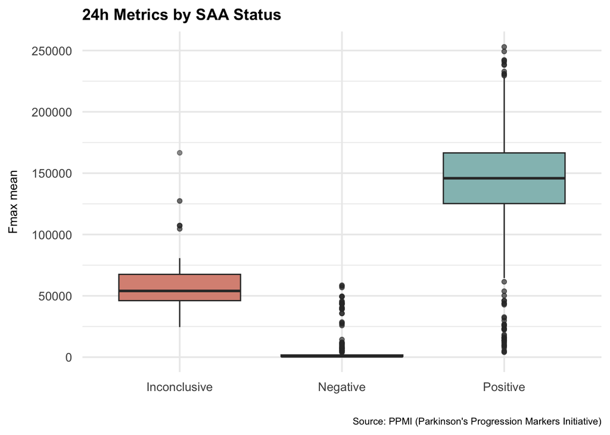

```r
fmax_mean_results_24h
```

```r
ggsave(filename = "../results/06_fmax_mean_results_24h.png",
       width = 10,
       height = 5)
```

```r
filtered_237 <- aug_data |>
  filter(saa_result %in% c("Positive",
                           "Negative"),
         project == "237") |>

  drop_na(fmax_mean) |>

  select(patient_number,
         saa_result,
         fmax_mean)

filtered_237 |> count(saa_result)
```

```
# A tibble: 2 × 2
  saa_result     n
  <chr>      <int>
1 Negative     729
2 Positive    3714
```

```r
t.test(fmax_mean ~ saa_result,
       data = filtered_237)
```

```
    Welch Two Sample t-test

data:  fmax_mean by saa_result
t = -179.74, df = 3384.4, p-value < 2.2e-16
alternative hypothesis: true difference in means between group Negative and group Positive is not equal to 0
95 percent confidence interval:
 -139880.3 -136861.5
sample estimates:
mean in group Negative mean in group Positive
               5466.35              143837.26
```

Here we also show the ability to visually distinguish between the groups and we show a highly statistically significant difference from the T-test.